# Finance Data Project- Zihan Wei

## Explore bank stocks from 2006 to 2016:

Bank of America

CitiGroup

Goldman Sachs

JPMorgan Chase

Morgan Stanley

Wells Fargo

```python
from pandas_datareader import data, wb
import pandas as pd
import numpy as np
import datetime
%matplotlib inline
```

```python
df=pd.read_pickle('all_banks')
```

check the table

```python
df.head()
```

| Bank Ticker Stock Info Date | BAC Open | BAC High | BAC Low | BAC Close | BAC Volume | C Open | C High | C Low | C Close | C Volume | ... | MS Open | MS High | MS Low | MS Close | MS Volume | WFC Open | WFC High | WFC Low | WFC Close | WFC Volume |
| --- | --- | --- | --- | --- | --- | --- | --- | --- | --- | --- | --- | --- | --- | --- | --- | --- | --- | --- | --- | --- | --- |
| 2006-01-03 | 46.92 | 47.18 | 46.15 | 47.08 | 16296700 | 490.0 | 493.8 | 481.1 | 492.9 | 1537660 | ... | 57.17 | 58.49 | 56.74 | 58.31 | 5377000 | 31.60 | 31.98 | 31.20 | 31.90 | 11016400 |
| 2006-01-04 | 47.00 | 47.24 | 46.45 | 46.58 | 17757900 | 488.6 | 491.0 | 483.5 | 483.8 | 1871020 | ... | 58.70 | 59.28 | 58.35 | 58.35 | 7977800 | 31.80 | 31.82 | 31.36 | 31.53 | 10871000 |
| 2006-01-05 | 46.58 | 46.83 | 46.32 | 46.64 | 14970900 | 484.4 | 487.8 | 484.0 | 486.2 | 1143160 | ... | 58.55 | 58.59 | 58.02 | 58.51 | 5778000 | 31.50 | 31.56 | 31.31 | 31.50 | 10158000 |
| 2006-01-06 | 46.80 | 46.91 | 46.35 | 46.57 | 12599800 | 488.8 | 489.0 | 482.0 | 486.2 | 1370250 | ... | 58.77 | 58.85 | 58.05 | 58.57 | 6889800 | 31.58 | 31.78 | 31.38 | 31.68 | 8403800 |
| 2006-01-09 | 46.72 | 46.97 | 46.36 | 46.60 | 15620000 | 486.0 | 487.4 | 483.0 | 483.9 | 1680740 | ... | 58.63 | 59.29 | 58.62 | 59.19 | 4144500 | 31.68 | 31.82 | 31.56 | 31.68 | 5619600 |

5 rows × 30 columns

grab in multi-level index, BAC data

```python
df.xs('BAC',1).head()
```

| Stock Info Date | Open | High | Low | Close | Volume |
| --- | --- | --- | --- | --- | --- |
| 2006-01-03 | 46.92 | 47.18 | 46.15 | 47.08 | 16296700 |
| 2006-01-04 | 47.00 | 47.24 | 46.45 | 46.58 | 17757900 |
| 2006-01-05 | 46.58 | 46.83 | 46.32 | 46.64 | 14970900 |
| 2006-01-06 | 46.80 | 46.91 | 46.35 | 46.57 | 12599800 |
| 2006-01-09 | 46.72 | 46.97 | 46.36 | 46.60 | 15620000 |

find the max Close price for BAC

```python
max_close=df.xs('BAC',1)['Close'].max()
max_close
```

```
54.9
```

max close price for each bank

```python
df.xs('Close',1,level=1).max()
```

```
Bank Ticker
BAC     54.90
C      564.10
GS     247.92
JPM     70.08
MS      89.30
WFC     58.52
dtype: float64
```

Calculate daily percent change of each bank (pt-p(t-1))/p(t-1)

```python
returns=df.xs('Close',1,level=1).pct_change()
returns.head()
```

| Bank Ticker Date | BAC | C | GS | JPM | MS | WFC |
| --- | --- | --- | --- | --- | --- | --- |
| 2006-01-03 | NaN | NaN | NaN | NaN | NaN | NaN |
| 2006-01-04 | -0.010620 | -0.018462 | -0.013812 | -0.014183 | 0.000686 | -0.011599 |
| 2006-01-05 | 0.001288 | 0.004961 | -0.000393 | 0.003029 | 0.002742 | -0.000951 |
| 2006-01-06 | -0.001501 | 0.000000 | 0.014169 | 0.007046 | 0.001025 | 0.005714 |
| 2006-01-09 | 0.000644 | -0.004731 | 0.012030 | 0.016242 | 0.010586 | 0.000000 |

```python
import seaborn as sns
import matplotlib.pyplot as plt
```

# Use plot to find patterns

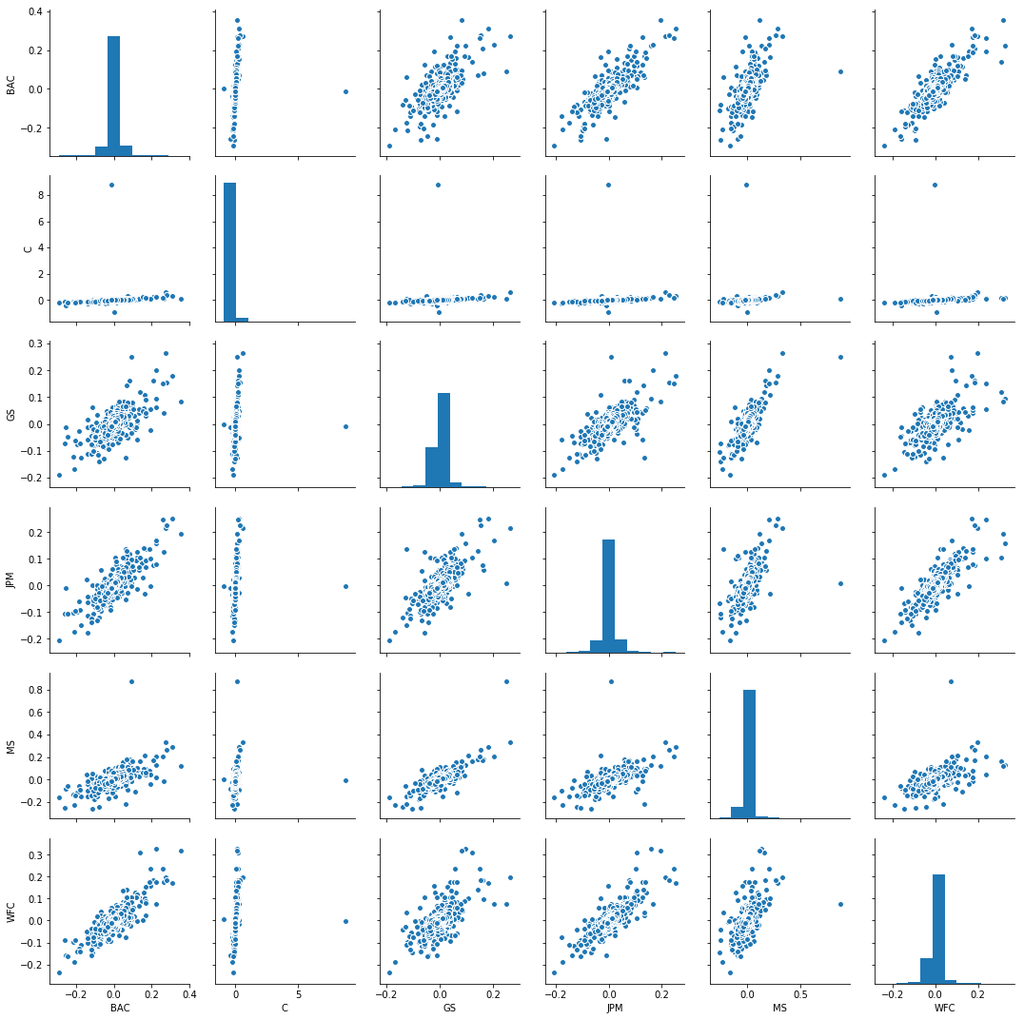

```python
sns.pairplot(returns.dropna())
```

Find the citi bank the max returns day

```python
returns[returns['C']==returns['C'].max(axis=0)]
```

| Bank Ticker Date | BAC | C | GS | JPM | MS | WFC |
| --- | --- | --- | --- | --- | --- | --- |
| 2011-05-09 | -0.010561 | 8.769912 | -0.006529 | -0.001776 | -0.006339 | -0.001416 |

Find each bank lowest return day

```python
returns.idxmin()
```

```
Bank Ticker
BAC   2009-01-20
C     2011-05-06
GS    2009-01-20
JPM   2009-01-20
MS    2008-10-09
WFC   2009-01-20
dtype: datetime64[ns]
```

Find each bank highest return day

```python
returns.idxmax()
```

```
Bank Ticker
BAC   2009-04-09
C     2011-05-09
GS    2008-11-24
JPM   2009-01-21
MS    2008-10-13
WFC   2008-07-16
dtype: datetime64[ns]
```

Standard deviation by bank

```python
returns.std()
```

```
Bank Ticker
BAC    0.036650
C      0.179969
GS     0.025346
JPM    0.027656
MS     0.037820
WFC    0.030233
dtype: float64
```

From above can see C(citi) is risky investment

```python
#set index t datetime, creat year column and month column
returns['year']=pd.to_datetime(returns.index).year
returns['month']=pd.to_datetime(returns.index).month
returns.head()
```

| Bank Ticker Date | BAC | C | GS | JPM | MS | WFC | year | month |
| --- | --- | --- | --- | --- | --- | --- | --- | --- |
| 2006-01-03 | NaN | NaN | NaN | NaN | NaN | NaN | 2006 | 1 |
| 2006-01-04 | -0.010620 | -0.018462 | -0.013812 | -0.014183 | 0.000686 | -0.011599 | 2006 | 1 |
| 2006-01-05 | 0.001288 | 0.004961 | -0.000393 | 0.003029 | 0.002742 | -0.000951 | 2006 | 1 |
| 2006-01-06 | -0.001501 | 0.000000 | 0.014169 | 0.007046 | 0.001025 | 0.005714 | 2006 | 1 |
| 2006-01-09 | 0.000644 | -0.004731 | 0.012030 | 0.016242 | 0.010586 | 0.000000 | 2006 | 1 |

plot shows all banks went through waves during 2008 and 2009, and variance start getting lower since 2011

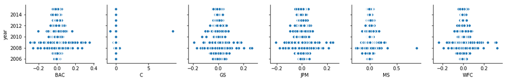

```python
sns.pairplot(returns.dropna(), x_vars=['BAC','C','GS','JPM','MS','WFC'],y_vars=['year'])
```

# Interestingly, the stock price seems to be steadier during May, June, and July, reasons?

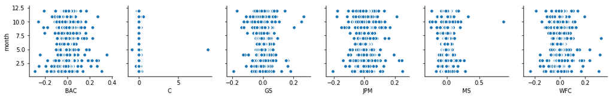

```python
sns.pairplot(returns.dropna(), x_vars=['BAC','C','GS','JPM','MS','WFC'],y_vars=['month'])
```

Std of year 2015, now citi is steady

```python
returns[returns['year']==2015].std()
```

```
Bank Ticker
BAC      0.016163
C        0.015289
GS       0.014046
JPM      0.014017
MS       0.016249
WFC      0.012591
year     0.000000
month    3.436303
dtype: float64
```

Distribution plot of returns of year 2015 of Morgan Stanley

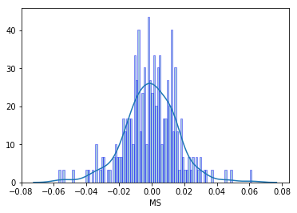

```python
ms_plot=returns[returns['year']==2015]['MS']
sns.distplot(ms_plot,bins=100,hist_kws={'edgecolor':'b'})
```

Distribution plot of returns of year 2008 of CITI

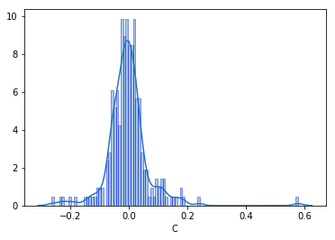

```python
c_plot=returns[returns['year']==2008]['C']
sns.distplot(c_plot,bins=100,hist_kws={'edgecolor':'b'})
```

For interactive plots

```python
import cufflinks as cf
import plotly
```

```python
cf.go_offline()
```

# Check the close price

```python
df.xs('Close',1,level=1).head()
```

| Bank Ticker Date | BAC | C | GS | JPM | MS | WFC |
| --- | --- | --- | --- | --- | --- | --- |
| 2006-01-03 | 47.08 | 492.9 | 128.87 | 40.19 | 58.31 | 31.90 |
| 2006-01-04 | 46.58 | 483.8 | 127.09 | 39.62 | 58.35 | 31.53 |
| 2006-01-05 | 46.64 | 486.2 | 127.04 | 39.74 | 58.51 | 31.50 |
| 2006-01-06 | 46.57 | 486.2 | 128.84 | 40.02 | 58.57 | 31.68 |
| 2006-01-09 | 46.60 | 483.9 | 130.39 | 40.67 | 59.19 | 31.68 |

```python
#plot the close price
```

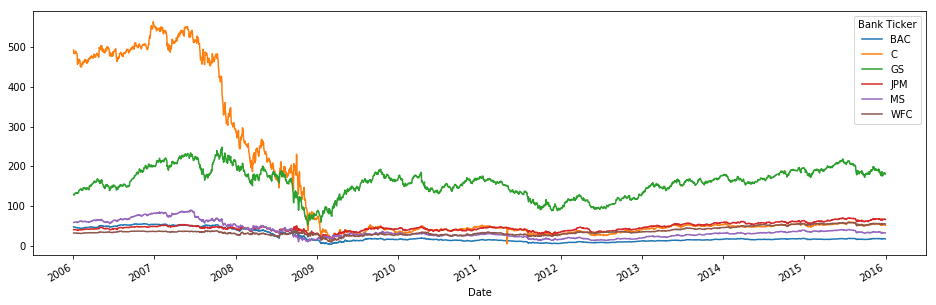

```python
df.xs('Close',1,level=1).plot(figsize=(16,5))
```

```python
#set 30-day moving average
bac_close=pd.DataFrame(df.xs('Close',axis=1,level=1)['BAC'])
bac_close['moving mean']=bac_close['BAC'].rolling(30).mean()
```

```python
#set date_time using list
bac_close['year']=pd.to_datetime(list(bac_close.reset_index()['Date'])).year
```

```python
bac_close[['BAC','moving mean']][bac_close['year']==2008].iplot()
```

[interactive chart not shown]

Draw heatmap and clustermap to check out correlations (discover relationships between banks)

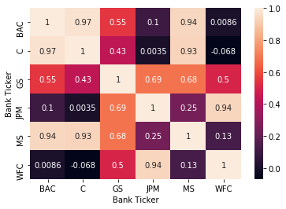

```python
df.xs('Close',axis=1,level=1).corr()
sns.heatmap(df.xs('Close',axis=1,level=1).corr(),annot=True)
```

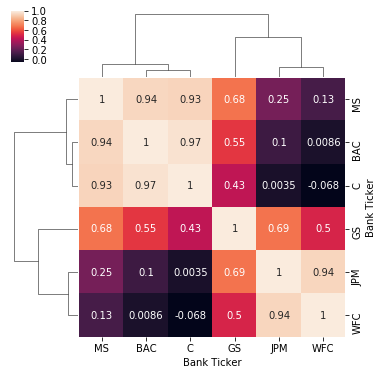

```python
sns.clustermap(df.xs('Close',axis=1,level=1).corr(),figsize=(6,6),annot=True)
```

```python
df['BAC'].ix['2008-01-01':'2010-01-01'].iplot('candle')
```

[interactive chart not shown]

```python
df['MS']['Close'].ix['2015-01-02':'2015-12-31'].ta_plot(study='boll')
```

[interactive chart not shown]

- Tip: Can use ix to select time period

```python
df.ix['2010-04-04':'2015-03-01'].head(2)
```

| Bank Ticker Stock Info Date | BAC Open | BAC High | BAC Low | BAC Close | BAC Volume | C Open | C High | C Low | C Close | C Volume | ... | MS Open | MS High | MS Low | MS Close | MS Volume | WFC Open | WFC High | WFC Low | WFC Close | WFC Volume |
| --- | --- | --- | --- | --- | --- | --- | --- | --- | --- | --- | --- | --- | --- | --- | --- | --- | --- | --- | --- | --- | --- |
| 2010-04-05 | 18.16 | 18.25 | 18.02 | 18.13 | 107989225 | 42.7 | 42.8 | 42.3 | 42.6 | 34453327 | ... | 29.28 | 29.49 | 29.13 | 29.29 | 11429691 | 31.49 | 31.75 | 31.26 | 31.51 | 30823818 |
| 2010-04-06 | 18.16 | 18.54 | 18.10 | 18.49 | 160316545 | 42.7 | 43.0 | 42.5 | 42.9 | 31812189 | ... | 29.25 | 29.62 | 28.96 | 29.36 | 13643730 | 31.36 | 32.39 | 31.35 | 32.28 | 39504856 |

2 rows × 30 columns